# Life Expectancy in Baltimore

Yifan Zhou

September 15, 2016

# 1.Introduction

The inequality in Baltimore has been a big issue:

*“Roland Park would be the 4th longest-living country in the world, while Seton Hill would be the 230th. Fourteen Baltimore neighborhoods have lower life expectancies than North Korea. Eight are doing worse than Syria.”* (Christopher Ingraham, The Washington Post, 2015)

In this study, we focus on life expectancy on block level in Baltimore City. Our goal is to develop a model for predicting life expectancy in Baltimore down to single block resolution with estimates of uncertainty.

# 2.Method

## 2.1 Definition

For geographic information about blocks in Baltimore, we use the Tiger shape files from [Census 2010](http://www.mdp.state.md.us/msdc/S5_Map_GIS.Shtml), from which we obtained block ID, coordinates and footprint for each block. There are 13488 blocks defined by Census 2010, and we use the polygon center of each block (black dots in Fig1) to calculate the map distance between two locations. For calculating distance, we use Google Maps API through R package “ggmap”.

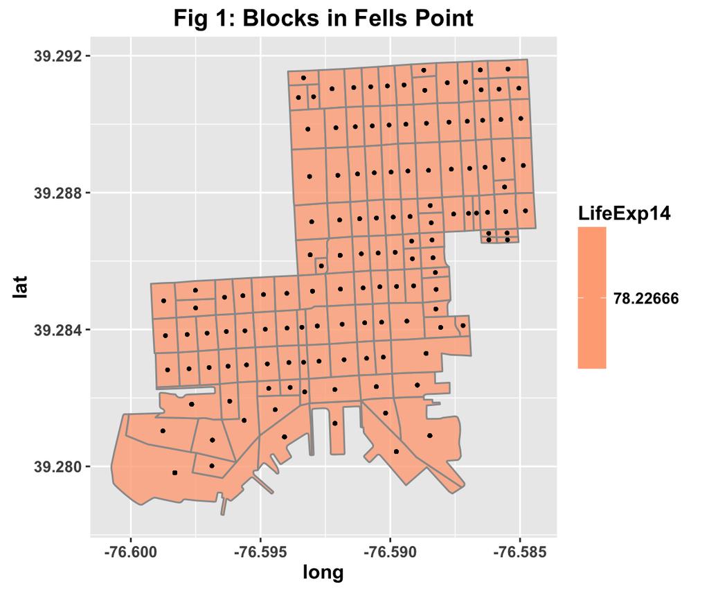

## 2.2 Data

> Outcome variable:

We could obtain the life expectancy data in 2014 for Baltimore City on neighborhood level as the outcome variable (http://bniajfi.org/vital_signs/data_downloads/). There are 55 neighborhoods in Baltimore City, we use the definition of “CSA2010” in Census 2010 shape files to get the geographic information of thoses neighborhoods.

[figure not shown]

> independent variable:

Since life expectancy is associated with many kinds of factors such as family disease history, individual body condition, environment and socioeconomic factors. We consider those following factors as the potential predictors for the predicting model of life expectancy:

- Demographics: Age, gender, race…
- Socioeconomic Characteristics: Income, Employment rate, poverty rate, percent of single-parent households…
- Education: Reading proficiency, School absenteeism, adult education attainment…
- Community Built and Social Environment: Alcohol/tobacco store density, juvenile arrest rate, domestic violence rate…
- Housing: Lead paint violation rate, energy cut-off rate…
- Food Environment: Fast food density, carryout density, corner store density, supermarket proximity…
- Health Outcomes: premature mortality, avertable deaths, top ten casuses of death…

Most of the neighborhood data are Census data downloaded from [BNIA](http://bniajfi.org/vital_signs/data_downloads/). And most of the lock level data are from datasets containing location information such as address and coordinates downloaded from [Open Baltimore](https://data.baltimorecity.gov/)

From the previous section, we could see there are plenty of data resources on neighborhood level from many aspects like health, socioeconomic, public safety, and housing. However, we need to narrow down the range of potential predictors since lots of them are highly correlated such as crime rate and violent crime rate, number of demolition permits and vacant building. After several steps of selection, I choose 22 variables as the potential predictors which are shown as below:

```
##  [1] "Number of Businesses that are Arts-Related per 1,000 residents (2014)"
##  [2] "Number of Persons with Library Cards per 1,000 Residents (2014)"
##  [3] "Public Art per 1,000 Residents (2014)"
##  [4] "Number of Public Murals (2014)"
##  [5] "Number of Event Permits Requested per 1,000 Residents (2014)"
##  [6] "Part 1 Crime Rate per 1,000 Residents (2014)"
##  [7] "Juvenile Arrest Rate per 1,000 Juveniles (2011)"
##  [8] "Number of Shootings per 1,000 Residents (2012)"
##  [9] "Number of Common Assault Calls for Service per 1,000 Residents (2012)"
## [10] "Number of Automobile Accident Calls for Service per 1,000 Residents (2012)"
## [11] "Number of Homes Sold (2014)"
## [12] "Median Price of Homes Sold (2014)"
## [13] "Median Number of Days on the Market (2014)"
## [14] "Total Number of Residential Properties (2014)"
## [15] "Number of Homeowner's Tax Credits per 1,000 Residential Units (2014)"
## [16] "Percentage of Residential Properties that are Vacant and Abandoned (2014)"
## [17] "Unemployment Rate (2010-2014)"
## [18] "Walk Score (2011)"
## [19] "Liquor Outlet density (per 1,000 Residents) (2014)"
## [20] "Total Number of Households (2010)"
## [21] "Average Household Size (2010)"
## [22] "Median Household Income (2010-2014)"
```

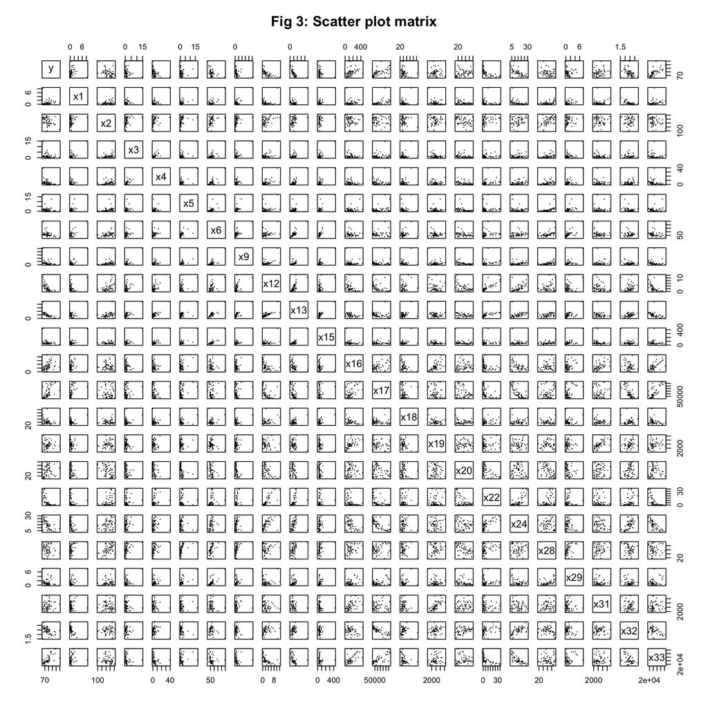

Since health environment is highly correlated with life expectancy, I also add several variables which are representative of health enviroment: Lead Paint Violations, density of hospitals/nursing homes/shelters.

| Number | Neighborhood level variables | Block level variables |
| --- | --- | --- |
| 1 | Number of Arts-Related Businesses | Baltimore Arts Organizations |
| 2 | Number of Persons with Library Cards | Libraries Location |
| 3 | Public Art | Public Art Inventory |
| 4 | Number of Public Murals | Monuments, Museums, Designated Landmarks |
| 5 | Number of Event Permits Requested | Special event permits |
| 6 | Part 1 Crime Rate | BPD Part 1 Victim Based Crime Data |
| 7 | Juvenile Arrest Rate | BPD Arrests Data |
| 8 | Number of Shootings | BPD Part 1 Victim Based Crime Data |
| 9 | Number of Common Assault Calls for Service | Calls for Service |
| 10 | Number of Automobile Accident Calls for Service | Calls for Service |
| 11 | Number of Homes Sold | … |
| 12 | Median Price of Homes Sold | … |
| 13 | Median Number of Days on the Market | Zillow API Data |
| 14 | Total Number of Residential Properties | Real Estate Value |
| 15 | Number of Homeowner’s Tax Credits | Real Property Taxes |
| 16 | Percentage of Residential Properties that are Vacant and Abandoned | Vacant Building, Vacant Houses |
| 17 | Unemployment Rate | … |
| 18 | Walk Score | Walk Score API |
| 19 | Liquor Outlet density | Liquor Stores Locations |
| 20 | Total Number of Households | Real Property Taxes, Area of each block |
| 21 | Average Household Size | Real Property Taxes, Area of each block |
| 22 | Median Household Income | Real Estate Value, Real Property Taxes |

# 3 Statistical Method

We want to predict life expectancy for the 13488 blocks in Baltimore City. However, we could only obtain life expectancy data as the outcome variable on neighborhood level. Therefore, we couldn’t build up the prediction model directly on block level. In this study, we decide to use a glm method to train a prediction model by using neighborhood data, then plug in the block level predictors into this model and obtain the prediction values for each block. Since it’s impossible to obtain the predictors for neighborhood level and block level on the same scale (for example, we couldn’t get the median home income for each block), we need to estimate several predictors for blocks so that we can plug in them into the prediction model built on neighborhood data.

## 3.1 Model

Since the outcome variable is continuous and the number of observations are not very large (we have 55 neighbor), we could use generalized linear model. According to the simple glm regression result (comparing the AIC) and the distribution of the outcome variable in the plots above, I decide the use the “Gamma” family on glm.

Use cross validation to evaluate different models then choose one with the best performance.

```
##
## Call:  glm(formula = y ~ x1 + x2 + x3 + x4 + x5 + x6 + x9 + x12 + x13 +
##     x15 + x16 + x17 + x18 + x19 + x20 + x22 + x24 + x28 + x29 +
##     x31 + x32 + x33, family = "gaussian", data = data2)
##
## Coefficients:
## (Intercept)           x1           x2           x3           x4
##   6.555e+01   -6.779e-01   -2.840e-03   -1.193e-01    7.034e-02
##          x5           x6           x9          x12          x13
##  -1.763e-02   -3.737e-02   -6.122e-03    4.940e-02   -1.623e-02
##         x15          x16          x17          x18          x19
##   4.538e-02   -7.336e-03    2.159e-05   -2.258e-02   -5.348e-04
##         x20          x22          x24          x28          x29
##   2.138e-02   -2.106e-02    1.301e-02    4.433e-02   -4.974e-01
##         x31          x32          x33
##   9.177e-04    7.230e-01    7.876e-05
##
## Degrees of Freedom: 50 Total (i.e. Null);  28 Residual
##   (4 observations deleted due to missingness)
## Null Deviance:       664.8
## Residual Deviance: 87.99     AIC: 220.5
```

```
##
## Call:  glm(formula = y ~ x1 + x2 + x3 + x4 + x5 + x6 + x9 + x12 + x13 +
##     x15 + x16 + x17 + x18 + x19 + x20 + x22 + x24 + x28 + x29 +
##     x31 + x32 + x33, family = Gamma(link = "inverse"), data = data2)
##
## Coefficients:
## (Intercept)           x1           x2           x3           x4
##   1.487e-02    1.313e-04    4.766e-07    1.649e-05   -1.281e-05
##          x5           x6           x9          x12          x13
##   3.080e-06    5.968e-06    1.063e-06   -9.067e-06    3.867e-06
##         x15          x16          x17          x18          x19
##  -8.309e-06    1.157e-06   -3.701e-09    4.044e-06    9.911e-08
##         x20          x22          x24          x28          x29
##  -4.321e-06    4.857e-06   -1.949e-06   -7.948e-06    8.331e-05
##         x31          x32          x33
##  -1.621e-07   -8.263e-05   -1.286e-08
##
## Degrees of Freedom: 50 Total (i.e. Null);  28 Residual
##   (4 observations deleted due to missingness)
## Null Deviance:       0.1224
## Residual Deviance: 0.01487   AIC: 215.2
```

```
##
## Call:  glm(formula = y ~ x1 + x2 + x3 + x4 + x5 + x6 + x9 + x12 + x13 +
##     x15 + x16 + x17 + x18 + x19 + x20 + x22 + x24 + x28 + x29 +
##     x31 + x32 + x33, family = Gamma(link = "log"), data = data2)
##
## Coefficients:
## (Intercept)           x1           x2           x3           x4
##   4.198e+00   -9.493e-03   -3.408e-05   -1.470e-03    1.027e-03
##          x5           x6           x9          x12          x13
##  -3.749e-04   -4.450e-04   -7.362e-05    5.542e-04   -2.650e-04
##         x15          x16          x17          x18          x19
##   5.938e-04   -8.927e-05    2.737e-07   -2.829e-04   -7.455e-06
##         x20          x22          x24          x28          x29
##   3.002e-04   -2.792e-04    1.316e-04    5.720e-04   -6.198e-03
##         x31          x32          x33
##   1.209e-05    7.651e-03    1.029e-06
##
## Degrees of Freedom: 50 Total (i.e. Null);  28 Residual
##   (4 observations deleted due to missingness)
## Null Deviance:       0.1224
## Residual Deviance: 0.01547   AIC: 217.2
```

## 3.2 Data Transform

Such as normalization, log tranform, spline…

## 3.3 Variable Selection

Use likelihood ratio test to select suitable independent variables.

## 3.4 Train Model

## 3.5 Apply model on block level data

# Question

- It’s difficult to find block level education & health data and numbers of residents in each block. Can I use the estimated values as the predictors then plug them into the exist model? Or use the proportion of area for each block to estimate numbers of residents.
- Could I use the data from other city such Chicago, New York and LA to train the prediction model?

# 4.Result

# 5.Discussion

# 6.Reference